# A Machine Learning Predictor: Human Activity Recognition

[Richard Hardy](https://github.com/rphardy)

2020-01-16

## Summary Report:

### How the model was built:

Sensor measures were selected from the raw data as potential features, while variables related to the experimental design were removed. Dropped variables were: “X”, “user_name”, “raw_timestamp_part_1”, “raw_timestamp_part_2”, “cvtd_timestamp”, “new_window”, “num_window”.

Variables contaning missing data in the target test set were dropped, based on the pattern of missingess, whereby data was either complete, or completely missing for each sensor measure variable in the test set.

Then, the variables retained in the test set were retained in the training set, providing a test and training dataset consisting of the direct HAR measurement data only (problem_id was also dropped from the test set).

In the context of this assignment, a high degree of accuracy and training speed were the most important ML model considerations. Therefore, Random Forest was chosen as an initial technique, as it was likely to produce the greatest accuracy, and a parallel processing method was used to improve the training speed:

see Len Greski’s method.

### Cross Validation

Caret automates the cross-validation process when fitting a random forest model.

5-fold cross-validation was specified and gave an accuracy: .993 to .996 across 5 folds.

### Out of sample error:

The model produced a 0.44% out-of-sample error, see the oob error based on the 5-fold cross-validation.

### Prediction model - 20 different test cases:

20/20 activity types were identified as the correct one of movement class A,B,C,D,E using the 20 cases contained in the test set.

## Method

### Data Preprocessing

- test set contains 160 variables, including `problem_id`. 100 variables contain entirely missing data. These are removed, leaving complete data for 60 vars.
- `problem_id` is not present in the training set, and not required for prediction in the testing set, thus it is dropped from test set.
- 52 variables are retained in the training set data, with “classe” added, providing clean homogenous training and testing sets for the ML modelling.
- 3 variables required class to be edited to match in training and test sets.

```r
trainUrl <- "https://d396qusza40orc.cloudfront.net/predmachlearn/pml-training.csv"
testUrl <- "https://d396qusza40orc.cloudfront.net/predmachlearn/pml-testing.csv"

download.file(trainUrl, destfile = "train.csv")
download.file(testUrl, destfile = "test.csv")

trainSetRaw <- read.csv("train.csv")
testSetRaw <- read.csv("test.csv")

projectCitation <- "http://groupware.les.inf.puc-rio.br/har"
paperCitation <- "Velloso, E.; Bulling, A.; Gellersen, H.; Ugulino, W.;
Fuks, H. Qualitative Activity Recognition of Weight Lifting Exercises.
Proceedings of 4th International Conference in Cooperation with SIGCHI
(Augmented Human '13) . Stuttgart, Germany: ACM SIGCHI, 2013."

## Code to remove the columns with missing values in the test set:
nmissingTest <- NULL
        for (i in 1:160) { nmissingTest <- c(nmissingTest, sum(is.na(testSetRaw[,i])))}
nmissingTest
```

```
##   [1]  0  0  0  0  0  0  0  0  0  0  0 20 20 20 20 20 20 20 20 20 20 20 20 20 20
##  [26] 20 20 20 20 20 20 20 20 20 20 20  0  0  0  0  0  0  0  0  0  0  0  0  0 20
##  [51] 20 20 20 20 20 20 20 20 20  0  0  0  0  0  0  0  0  0 20 20 20 20 20 20 20
##  [76] 20 20 20 20 20 20 20 20  0  0  0 20 20 20 20 20 20 20 20 20 20 20 20 20 20
## [101] 20  0 20 20 20 20 20 20 20 20 20 20  0  0  0  0  0  0  0  0  0  0  0  0 20
## [126] 20 20 20 20 20 20 20 20 20 20 20 20 20 20  0 20 20 20 20 20 20 20 20 20 20
## [151]  0  0  0  0  0  0  0  0  0  0
```

```r
sum(nmissingTest==0) # 60 vars with complete data.
```

```
## [1] 60
```

```r
testSetClean <- testSetRaw[c(8:11,37:49,60:68,84:86,102,113:124,140,151:160)]
testSetClean$magnet_dumbbell_z <- as.numeric(testSetClean$magnet_dumbbell_z)
testSetClean$magnet_forearm_y <- as.numeric(testSetClean$magnet_forearm_y)
testSetClean$magnet_forearm_z <- as.numeric(testSetClean$magnet_forearm_z)
ncol(testSetClean) # 53 vars retained
```

```
## [1] 53
```

```r
testSetClean <- testSetClean[1:52] #drop problem_id


# name of vars to use in the train set
trainVarsToKeep <- c(names(testSetClean),"classe")

trainVarsToKeep %in% names(trainSetRaw) # all accounted for in training set
```

```
##  [1] TRUE TRUE TRUE TRUE TRUE TRUE TRUE TRUE TRUE TRUE TRUE TRUE TRUE TRUE TRUE
## [16] TRUE TRUE TRUE TRUE TRUE TRUE TRUE TRUE TRUE TRUE TRUE TRUE TRUE TRUE TRUE
## [31] TRUE TRUE TRUE TRUE TRUE TRUE TRUE TRUE TRUE TRUE TRUE TRUE TRUE TRUE TRUE
## [46] TRUE TRUE TRUE TRUE TRUE TRUE TRUE TRUE
```

```r
trainSetClean <- subset(trainSetRaw, select = trainVarsToKeep)
```

### Exploratory Analysis

```r
expLayout <- ggplot(data=trainSetRaw, aes(x=classe, y=cvtd_timestamp, col=user_name))+geom_point(alpha=0.25)
```

## Building the Model

```r
cluster <- makeCluster(detectCores() - 1) # convention to leave 1 core for OS
registerDoParallel(cluster)

fitControl <- trainControl(method = "cv",
                           number = 5,
                           allowParallel = TRUE)

set.seed(13425)
fit <- train(classe ~ . , method="rf", data=trainSetClean, trControl = fitControl)

stopCluster(cluster)
registerDoSEQ()

fit
```

```
## Random Forest
##
## 19622 samples
##    52 predictor
##     5 classes: 'A', 'B', 'C', 'D', 'E'
##
## No pre-processing
## Resampling: Cross-Validated (5 fold)
## Summary of sample sizes: 15698, 15699, 15697, 15697, 15697
## Resampling results across tuning parameters:
##
##   mtry  Accuracy   Kappa
##    2    0.9946489  0.9932310
##   27    0.9940884  0.9925220
##   52    0.9884827  0.9854305
##
## Accuracy was used to select the optimal model using the largest value.
## The final value used for the model was mtry = 2.
```

```r
fit$resample
```

```
##    Accuracy     Kappa Resample
## 1 0.9954128 0.9941966    Fold1
## 2 0.9949019 0.9935508    Fold2
## 3 0.9956688 0.9945217    Fold5
## 4 0.9926115 0.9906537    Fold4
## 5 0.9946497 0.9932324    Fold3
```

```r
confusionMatrix.train(fit)
```

```
## Cross-Validated (5 fold) Confusion Matrix
##
## (entries are percentual average cell counts across resamples)
##
##           Reference
## Prediction    A    B    C    D    E
##          A 28.4  0.1  0.0  0.0  0.0
##          B  0.0 19.2  0.1  0.0  0.0
##          C  0.0  0.0 17.3  0.2  0.0
##          D  0.0  0.0  0.0 16.1  0.1
##          E  0.0  0.0  0.0  0.0 18.3
##
##  Accuracy (average) : 0.9946
```

```r
fit$finalModel
```

```
##
## Call:
##  randomForest(x = x, y = y, mtry = param$mtry)
##                Type of random forest: classification
##                      Number of trees: 500
## No. of variables tried at each split: 2
##
##         OOB estimate of  error rate: 0.44%
## Confusion matrix:
##      A    B    C    D    E  class.error
## A 5578    2    0    0    0 0.0003584229
## B   13 3782    2    0    0 0.0039504872
## C    0   17 3403    2    0 0.0055523086
## D    0    0   42 3171    3 0.0139925373
## E    0    0    0    5 3602 0.0013861935
```

```r
rfPrediction <- predict(fit, newdata = testSetClean)
# Achieves 20/20 on test set - output not displayed, in accordance with honour code
```

## Appendix

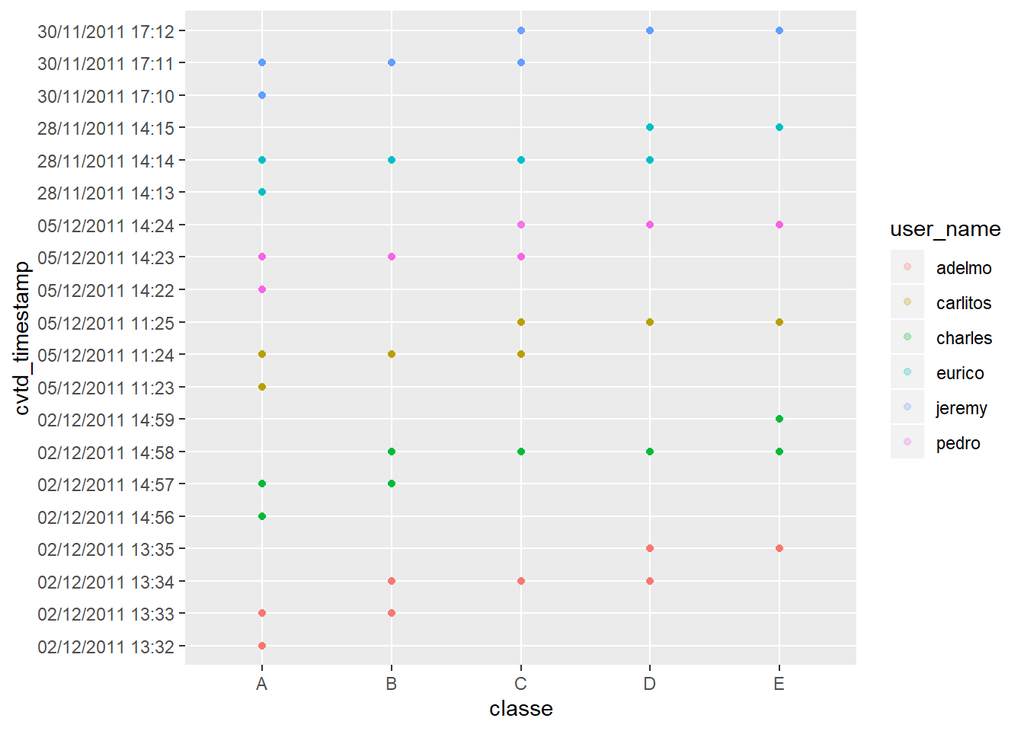

```r
expLayout # this sketch plot shows the experiment's temporal structure.
```

```r
fit$coefnames # full list of coefficients included in the random forest model
```

```
##  [1] "roll_belt"            "pitch_belt"           "yaw_belt"
##  [4] "total_accel_belt"     "gyros_belt_x"         "gyros_belt_y"
##  [7] "gyros_belt_z"         "accel_belt_x"         "accel_belt_y"
## [10] "accel_belt_z"         "magnet_belt_x"        "magnet_belt_y"
## [13] "magnet_belt_z"        "roll_arm"             "pitch_arm"
## [16] "yaw_arm"              "total_accel_arm"      "gyros_arm_x"
## [19] "gyros_arm_y"          "gyros_arm_z"          "accel_arm_x"
## [22] "accel_arm_y"          "accel_arm_z"          "magnet_arm_x"
## [25] "magnet_arm_y"         "magnet_arm_z"         "roll_dumbbell"
## [28] "pitch_dumbbell"       "yaw_dumbbell"         "total_accel_dumbbell"
## [31] "gyros_dumbbell_x"     "gyros_dumbbell_y"     "gyros_dumbbell_z"
## [34] "accel_dumbbell_x"     "accel_dumbbell_y"     "accel_dumbbell_z"
## [37] "magnet_dumbbell_x"    "magnet_dumbbell_y"    "magnet_dumbbell_z"
## [40] "roll_forearm"         "pitch_forearm"        "yaw_forearm"
## [43] "total_accel_forearm"  "gyros_forearm_x"      "gyros_forearm_y"
## [46] "gyros_forearm_z"      "accel_forearm_x"      "accel_forearm_y"
## [49] "accel_forearm_z"      "magnet_forearm_x"     "magnet_forearm_y"
## [52] "magnet_forearm_z"
```